# Churchill_D213_T1

Briana Churchill

011009463

Dr. William Sewell

2024 May 22

## Part I: Research Question

### A. Purpose of the data analysis

#### A1. Research question

Using two years of available data, can accurate predictions be made regarding the daily revenue for WGU Teleco?

#### A2. Goals of the data analysis

The goals of this analysis are to:

- Plot original datetime series to check for patterns/stationarity
- Compare ACF/PACF values to auto ARIMA values to determine the best model
- Create a visualization that encompasses all of the data (test, train and predictions)

These goals are attainable because they are consistent with measures needed for a time series analysis.

## Part II: Method Justification

### B. Assumptions of a time series model

In creating this time series analysis, an ARMA or ARIMA model will be created. The assumptions of such a time series, detailed in the "Arima simplified" article are as follows:

- No anomalies or outliers are present in the dataset
  - The dataset was tested for null values and outliers prior to implementing the ARIMA model chosen.
- The data must be stationary
  - This means that the data can not contain trends, which is why the dataset was differenced as mentioned above.
- Historical data can be used to predict future behavior of one dependent variable (Revenue for this model)
  - This is why seasonal data can not be used in a time series model, because behavior related to purchasing fireworks around the 4th of July would cause skewed data for all other periods of time in the year.
    - If historical data shows correlation to present data, then an auto regressive (AR) model will be used because there is partial autocorrelation.
    - When errors exist in a previously used time series model, the effect of the errors from the previous observation is used to create a better model for present data. Using previous errors (auto-correlation) results in creating a moving average (MA) model.

## Part III: Data Preparation

### C. Summarize the data cleaning process

#### C1. Line graph visualizing the realization of the time series

To prepare the data for the ARIMA model, it needed to be cleaned. Starting with the "Day" column, the values were transformed to a data format (YYYY-MM-DD) because the data was originally measured in numbers such as 1,2, and so on. Because there were 731 instances of values in the "Day" column, it was evident that the dataset consisted of 2 years of data. However the data dictionary did not detail which years the data was for. Because of this, the dates were transformed to start a little over two years ago on January 1st, 2022 using the datetime module in Python. Once the values were updated, the "Day" column was set as the index of the dataset and any null values were dropped. Once these steps were taken care of, the plot was created and can be seen in step 2 below.

```python
# Import necessary libraries/packages
# Code references stackoverflow, geeks for geeks and Dr. Sewell
import pandas as pd
import numpy as np
import matplotlib.pyplot as plt
import warnings
warnings.filterwarnings("ignore")
from matplotlib.pylab import rcParams
rcParams['figure.figsize']= 10,6
# import csv
df = pd.read_csv('./teleco_time_series.csv')
# Convert Day numbers to dates using datetime
import datetime
ref = datetime.datetime(2022, 1, 1)
Date = [ref + datetime.timedelta(days=d-1) for d in df['Day']]
df['Day'] = Date
#set index & drop any nulls
df = df.set_index(['Day'])
df.dropna(inplace=True)
#review
df.info()
```

```
<class 'pandas.core.frame.DataFrame'>
DatetimeIndex: 731 entries, 2022-01-01 to 2024-01-01
Data columns (total 1 columns):
 #   Column   Non-Null Count  Dtype
---  ------   --------------  -----
 0   Revenue  731 non-null    float64
dtypes: float64(1)
memory usage: 11.4 KB
```

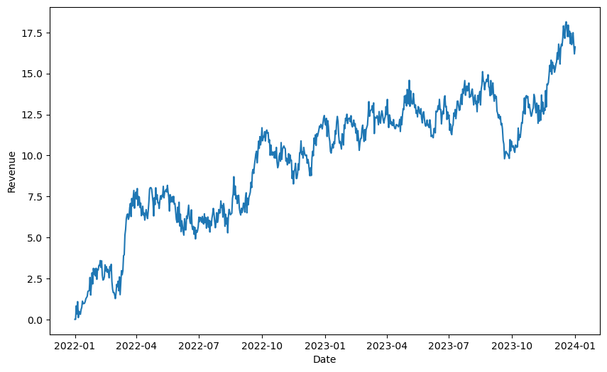

```python
# Create initial line graph
plt.xlabel('Date')
plt.ylabel('Revenue')
plt.plot(df)
```

#### C2. Time Step Formatting

Seen in the graph above, there were no gaps in measurement as there is consistent data from January 2022 until January 2024. This is expected considering two years of data was provided, and 01/01/2022 was made the start date as mentioned above using the datetime module. Before creating an ARIMA model and fitting it to the data, one would want to be sure that the dataset does not depict a trend. Considering the graph does show an upward trend overall, this was a clear indication that the data would need to be transformed further to ensure stationarity.

#### C3. Stationarity of the time series

Seen in step 3 below, a Dickey-Fuller test was completed utilizing code from Dr. Sewell's webinars. The critical values and ADF value are very close in measure, and the p-value was 0.32 which indicates that the data is not stationary. As such, the diff() function was used to find the difference of datapoints within each row as compared to the previous row, this is also known as differencing the data. Thus, the datapoints are now a value of difference between rows, rather than the original values.

```python
# DF test on original indexed data
# Code references Dr. Sewell webinar
from statsmodels.tsa.stattools import adfuller
print ('Results of Dickey-Fuller test: ')
dftest = adfuller(df['Revenue'], autolag='AIC')
dfoutput = pd.Series(dftest[0:4], index=['Test Statistic','p-value','#Lags Used','No. of Observations'])
for key,value in dftest[4].items():
	dfoutput['Critical Value (%s) '%key] = value # Critical Values should always be more than the test statistic
print(dfoutput)
```

```
Results of Dickey-Fuller test:
Test Statistic            -1.924612
p-value                    0.320573
#Lags Used                 1.000000
No. of Observations      729.000000
Critical Value (1%)       -3.439352
Critical Value (5%)       -2.865513
Critical Value (10%)      -2.568886
dtype: float64
```

```python
# Make the data stationary with diff(1), because diff(2) was not a good fit. Run ADF again
# Code references Dr. Sewell webinar
norm_df = df.diff().dropna()
from statsmodels.tsa.stattools import adfuller
def ad_test(norm_df):
    dftest = adfuller(norm_df, autolag = 'AIC')
    print("1. ADF: ", dftest[0])
    print("2. P-value: ", dftest[1])
    print("3. Num of Lags:", dftest[2])
    print("4. Num of Obs Used for ADF Regression and Critical Values Calc:", dftest[3])
    print("5. Critical Values: ")
    for key, val in dftest[4].items():
        print("\t",key,": ",val)
    print("P-value indicates strong evidence against the null hypothesis(Ho), reject the null hypothesis. Data is stationary")
ad_test(norm_df['Revenue'])
```

```
1. ADF:  -44.87452719387599
2. P-value:  0.0
3. Num of Lags: 0
4. Num of Obs Used for ADF Regression and Critical Values Calc: 729
5. Critical Values:
	 1% :  -3.4393520240470554
	 5% :  -2.8655128165959236
	 10% :  -2.5688855736949163
P-value indicates strong evidence against the null hypothesis(Ho), reject the null hypothesis. Data is stationary
```

```
<class 'pandas.core.frame.DataFrame'>
DatetimeIndex: 730 entries, 2022-01-02 to 2024-01-01
Data columns (total 1 columns):
 #   Column   Non-Null Count  Dtype
---  ------   --------------  -----
 0   Revenue  730 non-null    float64
dtypes: float64(1)
memory usage: 11.4 KB
```

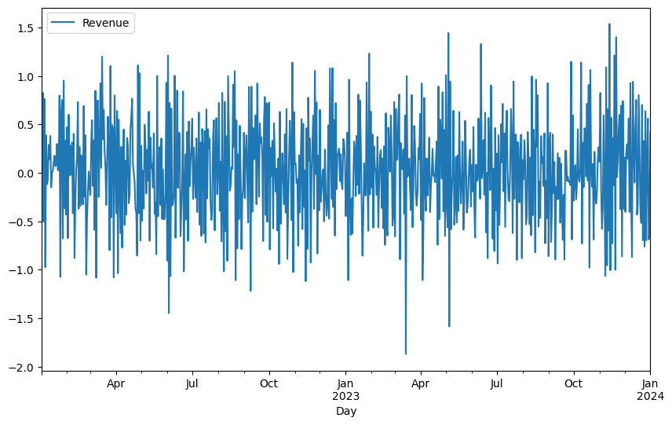

```python
# Plot differenced/stationary data
norm_df.plot()
norm_df.info()
```

#### C4. Preparing the data

Discussed previously, the data needed some cleaning and transformation prior to creating the time series analysis. The steps used were:

- Transforming "Day" column from integers to dates.
- Set data frame index as "Day"
- Difference the data using .diff()
- Drop null values

Additionally, in order to implement an ARIMA model and determine it's accuracy, it was necessary to split the dataset in two. "Test" which includes the last 90 days of the data, and "Train" which includes all other data. This split was easily executed by referencing Dr. Sewell's code from the first webinar regarding this assessment. The data set consisted of only two years of data, so 90 days was a reasonable time frame to make predictions with, as any predictions set for years out may not be as accurate given the limited historical data available.

```python
# Split data into testing/training set. Split data by last 90 days
# Code references Dr. Sewell webinar
train = norm_df.iloc[:-90]
test = norm_df.iloc[-90:]
print(train.shape, test.shape)
print(df.shape)
```

```
(640, 1) (90, 1)
(731, 1)
```

#### C5. Provide a copy of the cleaned data set

The cleaned date was saved as a csv file and uploaded for this assessment.

```python
# Save the cleaned DataFrame to CSV
df.to_csv('Norm_df.csv', index=False)
```

## Part IV: Model Identification and Analysis

### D. Analyze the time series data set by doing the following:

#### D1. Findings of the data analysis

Using the seasonal_decompose package: the trend, seasonality and residuals were obtained in step 8. Looking at the visual from the top, one can see the original data plotted, and then the trend plot underneath. Fortunately no significant trends can be seen, reassuring the stance that the data is stationary. There are some spikes in revenue at particular dates, but this could be related to many factors such as which day of the week more people shop or make purchases. This is especially true in my home state of Utah, where many individuals do not do any sort of business on Sundays. This likely plays into what can be seen on the next graph which depicts seasonality. The graph shows a repetitive pattern throughout the entire dataset. This graph does indicate slight seasonality, albeit insignificant considering the Dickey-Fuller test. Again, this seasonality can likely be chalked up to a majority of customers preferring to shop on a particular day of the week, rather than clear seasonality akin to pumpkin sales during October. The last plot seen from the decomposition visual is the residuals, also indicating consistently differing values and no particular trends.

Underneath the decomposition visual is the plotted ACF, PACF and spectral density. Mentioned in part B, the type of model (AR or MA) is determined based off the values of the ACF and PACF. ACF can determine the q value if an MA model is best, and PACF can determine the p value if an AR model is best. In both plots there are various datapoints, many being within the shaded areas of the graphs. These shaded datapoints are statistically insignificant, so we are looking for positive data points outside of that area. For ACF, this is a value of 2 and for PACF, there are no positive datapoints, so p=0. Therefore, the initial model will be created utilizing that q value [MA(q)], which results in ARIMA(0,0,2). See these visualizations below:

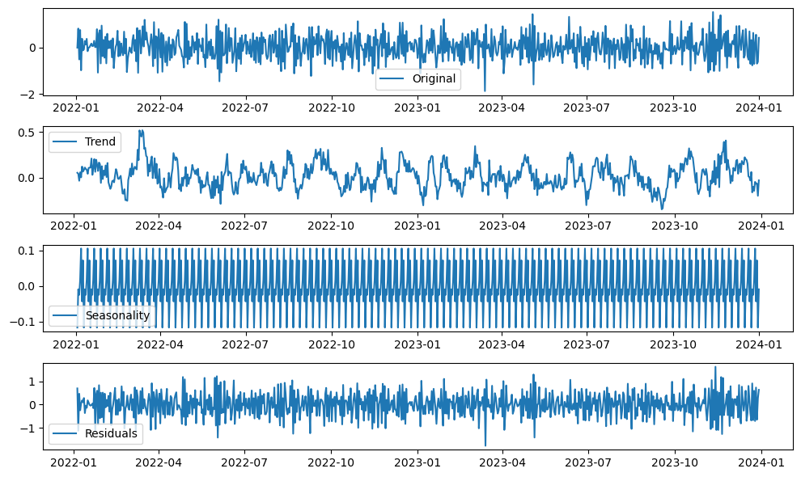

```python
# Obtain trend, seasonality and residuals from seasonal_decompose
# Code references Dr. Sewell webinar
from statsmodels.tsa.seasonal import seasonal_decompose
decomposition = seasonal_decompose(norm_df)
trend = decomposition.trend
seasonal = decomposition.seasonal
residual = decomposition.resid
plt.subplot(411)
plt.plot(norm_df, label='Original')
plt.legend(loc='best')
plt.subplot(412)
plt.plot(trend, label='Trend')
plt.legend(loc='best')
plt.subplot(413)
plt.plot(seasonal, label='Seasonality')
plt.legend(loc='best')
plt.subplot(414)
plt.plot(residual,label='Residuals')
plt.legend(loc='best')
plt.tight_layout()
```

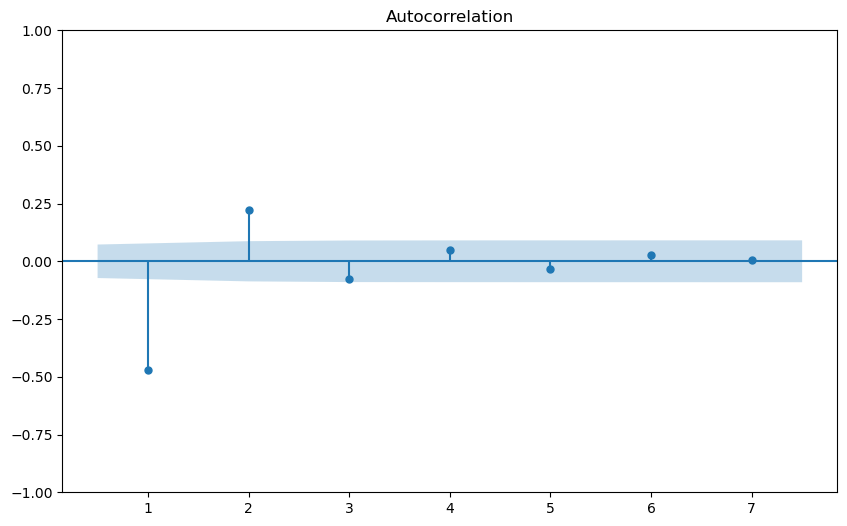

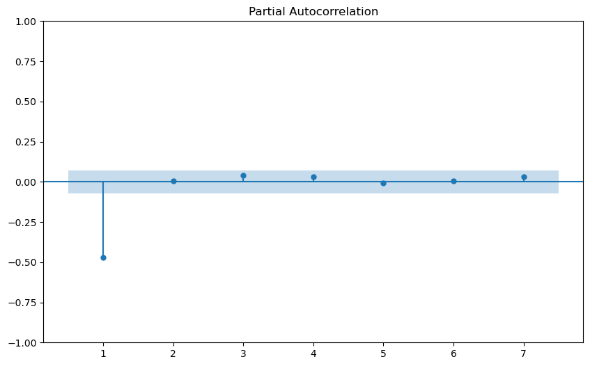

```python
# Plot ACF and PACF
# Code references stackoverflow, machinelearningmystery, and youtube
from matplotlib import pyplot
from statsmodels.graphics.tsaplots import plot_acf
plot_acf(norm_df, lags=7, zero=False)
pyplot.show()
from pandas import read_csv
from matplotlib import pyplot
from statsmodels.graphics.tsaplots import plot_pacf
plot_pacf(norm_df, lags=7, zero=False)
pyplot.show()
```

[figure not shown]

```python
# Plot spectral density
# Code references geeksforgeeks
import matplotlib.pyplot as plt
import numpy as np
import matplotlib.mlab as mlab
import matplotlib.gridspec as gridspec
# set random value
random_rep = np.random.RandomState(19680801)
frame_per_second = 1000
a = np.linspace(0, 0.3, 301)
b = np.array([2, 8]).reshape(-1, 1)
c = np.array([150, 140]).reshape(-1, 1)
d = (b * np.exp(2j * np.pi * c * a)).sum(axis = 0) + 5 * random_rep.randn(*a.shape)
figure, (a0, a1) = plt.subplots(ncols = 2,
								constrained_layout = True)
e = np.arange(-50, 30, 10)
f = (e[0], e[-1])
g = np.arange(-500, 550, 200)
a0.psd(d, NFFT = 301,
	Fs = frame_per_second,
	window = mlab.window_none,
	pad_to = 1024,
	scale_by_freq = True)
a0.set_title('Periodo-gram')
a0.set_yticks(e)
a0.set_xticks(g)
a0.grid(True)
a0.set_ylim(f)
a1.psd(d, NFFT = 150,
	Fs = frame_per_second,
	window = mlab.window_none,
	pad_to = 512,
	noverlap = 75,
	scale_by_freq = True)
a1.set_title('Welch')
a1.set_xticks(g)
a1.set_yticks(e)
# overwriting the y-label added by `psd`
a1.set_ylabel('')
a1.grid(True)
a1.set_ylim(f)
plt.show()
```

#### D2. Identify an (ARIMA) model that accounts for the observed trend and seasonality of the time series data

An initial model using the ACF and PACF values described above was created in addition to running auto_arima, which determines the best model for the data. Although I was hoping that the auto_arima would come back with the same model I first created (0,0,2), I was not surprised that it returned with a different value (1,0,0)(0,0,0). The second set of numbers are all zeros, which indicates that there is no seasonality. Therefore it was evident that the results from auto_arima were more appropriate for the data, so ARIMA(1,0,0) was created and utilized for the remainder of the analysis.

```python
# According to ACF, try ARIMA(0,0,2)
# Code references stackoverflow and Dr. Sewell webinar
from statsmodels.tsa.arima.model import ARIMA
import warnings
warnings.filterwarnings("ignore")
ma_model= ARIMA(train['Revenue'],order=(0,0,2), freq = 'D')
initial_model = ma_model.fit()
initial_model.summary()
```

SARIMAX Results

| Dep. Variable: | Revenue | No. Observations: | 640 |
| --- | --- | --- | --- |
| Model: | ARIMA(0, 0, 2) | Log Likelihood | -421.376 |
| Date: | Wed, 22 May 2024 | AIC | 850.752 |
| Time: | 17:58:30 | BIC | 868.598 |
| Sample: | 01-02-2022 | HQIC | 857.679 |
|  | - 10-03-2023 |  |  |
| Covariance Type: | opg |  |  |

|  | coef | std err | z | P>\|z\| | [0.025 | 0.975] |
| --- | --- | --- | --- | --- | --- | --- |
| const | 0.0166 | 0.014 | 1.169 | 0.242 | -0.011 | 0.044 |
| ma.L1 | -0.4353 | 0.038 | -11.368 | 0.000 | -0.510 | -0.360 |
| ma.L2 | 0.1990 | 0.040 | 5.015 | 0.000 | 0.121 | 0.277 |
| sigma2 | 0.2184 | 0.013 | 16.424 | 0.000 | 0.192 | 0.244 |

| Ljung-Box (L1) (Q): | 0.16 | Jarque-Bera (JB): | 2.92 |
| --- | --- | --- | --- |
| Prob(Q): | 0.69 | Prob(JB): | 0.23 |
| Heteroskedasticity (H): | 1.00 | Skew: | -0.08 |
| Prob(H) (two-sided): | 0.98 | Kurtosis: | 2.71 |

Warnings:  
[1] Covariance matrix calculated using the outer product of gradients (complex-step).

```python
# Run auto arima to find recommended ARIMA model
# Code references Dr. Sewell webinar
from pmdarima import auto_arima
import warnings
warnings.filterwarnings("ignore")
stepwise_fit=auto_arima(train['Revenue'],trace=True, suppress_warnings=True)
stepwise_fit.summary()
```

```
Performing stepwise search to minimize aic
 ARIMA(2,0,2)(0,0,0)[0] intercept   : AIC=851.096, Time=0.20 sec
 ARIMA(0,0,0)(0,0,0)[0] intercept   : AIC=992.906, Time=0.06 sec
 ARIMA(1,0,0)(0,0,0)[0] intercept   : AIC=847.028, Time=0.02 sec
 ARIMA(0,0,1)(0,0,0)[0] intercept   : AIC=875.628, Time=0.07 sec
 ARIMA(0,0,0)(0,0,0)[0]             : AIC=991.543, Time=0.02 sec
 ARIMA(2,0,0)(0,0,0)[0] intercept   : AIC=848.980, Time=0.06 sec
 ARIMA(1,0,1)(0,0,0)[0] intercept   : AIC=848.989, Time=0.08 sec
 ARIMA(2,0,1)(0,0,0)[0] intercept   : AIC=850.280, Time=0.27 sec
 ARIMA(1,0,0)(0,0,0)[0]             : AIC=846.716, Time=0.03 sec
 ARIMA(2,0,0)(0,0,0)[0]             : AIC=848.637, Time=0.04 sec
 ARIMA(1,0,1)(0,0,0)[0]             : AIC=848.653, Time=0.04 sec
 ARIMA(0,0,1)(0,0,0)[0]             : AIC=875.578, Time=0.05 sec
 ARIMA(2,0,1)(0,0,0)[0]             : AIC=849.696, Time=0.14 sec

Best model:  ARIMA(1,0,0)(0,0,0)[0]
Total fit time: 1.070 seconds
```

SARIMAX Results

| Dep. Variable: | y | No. Observations: | 640 |
| --- | --- | --- | --- |
| Model: | SARIMAX(1, 0, 0) | Log Likelihood | -421.358 |
| Date: | Wed, 22 May 2024 | AIC | 846.716 |
| Time: | 17:58:32 | BIC | 855.639 |
| Sample: | 01-02-2022 | HQIC | 850.180 |
|  | - 10-03-2023 |  |  |
| Covariance Type: | opg |  |  |

|  | coef | std err | z | P>\|z\| | [0.025 | 0.975] |
| --- | --- | --- | --- | --- | --- | --- |
| ar.L1 | -0.4524 | 0.035 | -12.962 | 0.000 | -0.521 | -0.384 |
| sigma2 | 0.2184 | 0.013 | 16.662 | 0.000 | 0.193 | 0.244 |

| Ljung-Box (L1) (Q): | 0.00 | Jarque-Bera (JB): | 1.88 |
| --- | --- | --- | --- |
| Prob(Q): | 0.97 | Prob(JB): | 0.39 |
| Heteroskedasticity (H): | 0.99 | Skew: | -0.04 |
| Prob(H) (two-sided): | 0.94 | Kurtosis: | 2.75 |

Warnings:  
[1] Covariance matrix calculated using the outer product of gradients (complex-step).

#### D3. Perform a forecast using the derived ARIMA model

Using the (AR)IMA model identified in part D2, the train data was used to predict the last 90 days of the dataset. As a reminder, the test data consists of the last 90 days, so it will be used to compare the predictions made to the actual data points. After the predictions were made, the predicted mean was plotted against the test data set in step 13. Then the model's root mean squared error was obtained to evaluate the model along with a final visualization of the original data, the test data, and the predictions. All of these steps can be seen below starting with step 13.

#### D4. Output and calculations of the analysis

See steps 13-16 below.

#### D5. Code used for time series model

See steps 13-16 below.

|  | lower Revenue | upper Revenue |
| --- | --- | --- |
| 2023-10-04 | -0.926936 | 0.902475 |
| 2023-10-05 | -1.901924 | 1.936463 |
| 2023-10-06 | -2.913359 | 2.969024 |
| 2023-10-07 | -3.919770 | 4.013747 |
| 2023-10-08 | -4.930814 | 5.055305 |
| ... | ... | ... |
| 2023-12-28 | -86.741753 | 89.535788 |
| 2023-12-29 | -87.751770 | 90.578752 |
| 2023-12-30 | -88.761787 | 91.621717 |
| 2023-12-31 | -89.771804 | 92.664682 |
| 2024-01-01 | -90.781821 | 93.707647 |

90 rows × 2 columns

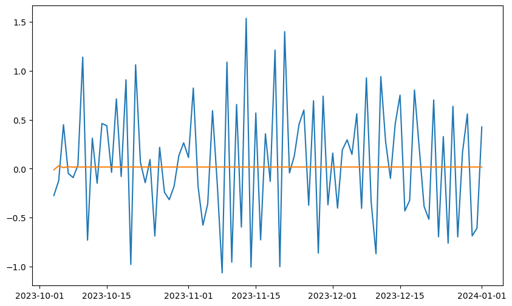

```python
# Best model from Auto arima: ARIMA(1,0,0)(0,0,0)[0]
# Code references stackoverflow and Dr. Sewell webinar
import statsmodels
from statsmodels.tsa.arima.model import ARIMA
#Create ARIMA(1,0,0)(0,0,0)[0]
final_model= ARIMA(train['Revenue'],order=(1,0,0), freq = 'D')
# fit the model and forecast
final_model = final_model.fit()
forecast = final_model.get_forecast(90)
prmean = forecast.predicted_mean
confidence = forecast.conf_int(alpha=0.05)
confidence
# Combined forecast with train dataset to show original and predictions
fcast = pd.DataFrame(forecast.predicted_mean)
fcast.rename(columns={'predicted_mean' : 'Revenue'}, inplace=True)
final_forecast = pd.concat([train.copy(), fcast.copy()])
# Invert values using cumsum()
final_forecast = final_forecast.cumsum()
confidence_intervals = confidence.cumsum()
plt.plot(test)
plt.plot(forecast.predicted_mean)
#set an index for plotting?
forecast.index=norm_df.index#[start:end+1]
confidence_intervals
```

```python
# Code references Dr. Sewell webinar
from sklearn.metrics import mean_squared_error
from math import sqrt
rmse = sqrt(mean_squared_error(final_forecast.Revenue.loc['2023-10-04' : '2024-01-01'],test, squared=False))
print(f"The root mean squared error is {round(rmse, 3)}")
```

```
The root mean squared error is 3.358
```

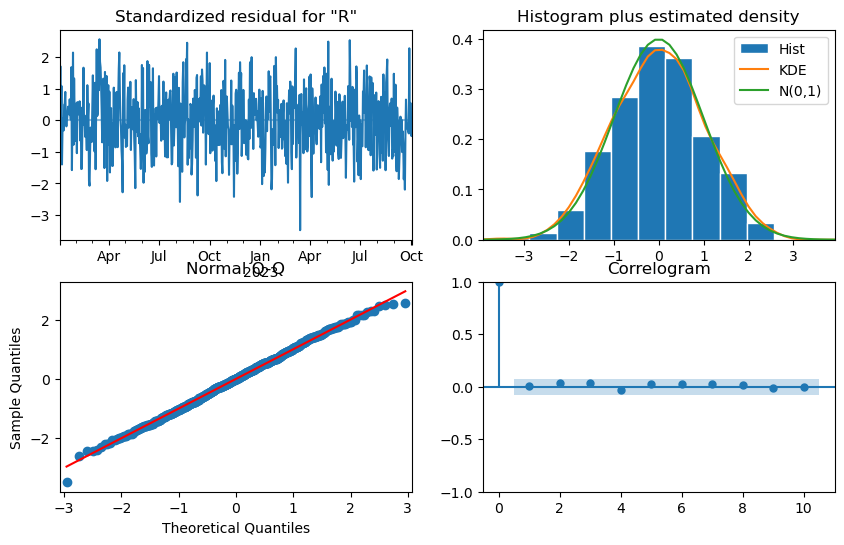

```python
# Plot diagnostics, code references stackoverflow for duplicate plotting
plt.figure(figsize = [10,6])
final_model.plot_diagnostics()
plt.show()
```

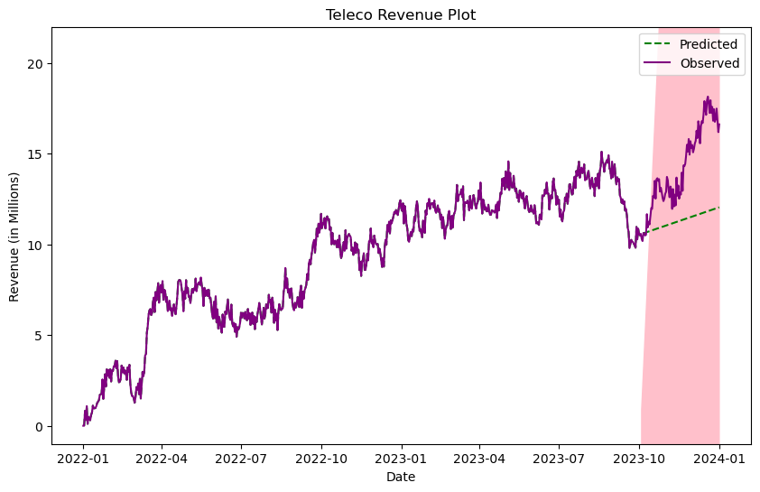

```python
# Create viz showing predictions vs observed
plt.title("Teleco Revenue Plot")
plt.xlabel("Date")
plt.ylabel("Revenue (in Millions)")
# Plot the forecasted data
plt.plot(final_forecast, color = 'green', linestyle = 'dashed')
# Plot the original data to compare
plt.plot(df, color = 'purple')
# Plot the confidence intervals
plt.fill_between(confidence_intervals.index, confidence_intervals['lower Revenue'], confidence_intervals['upper Revenue'], color = 'pink')
# Focus on applicable values with ylim
plt.ylim(-1, 22)
plt.legend(['Predicted', 'Observed'])
plt.show();
```

## Part V: Data Summary and Implications

### E. Summary

#### E1. Results of the data analysis

Based of the ACF and PACF models, an initial ARI(MA) model was created with order (0,0,2). However after tinkering with the model, it did not seem to be the best fit. Plus python has the auto_arima module readily available so it was utilized in an effort to be absolutely sure that the best model was chosen. Based off the results from auto_arima, a different model needed to be constructed. The final ARIMA model was created with order (1,0,0) because the auto_arima results implied that this particular order resulted in no seasonality which is a requirement for a time series analysis.

Predictions were made with the ARIMA model consisting of the train data. The prediction interval of the forecast is 90 days, between 10/04/2023 and 01/01/2024. Because the dataset is limited to two years, a small or medium forecast length is most appropriate which is why 90 days was used for this model. Although it would be beneficial to create long term predictions such as 5 years or more, there needs to be more data to ensure the most effective model considering historical data is used to create predictions. With such little historical data available, the model may not be as accurate as compared to a smaller forecast length.

Again referencing Dr. Sewell's code used in the course webinars, the root mean squared error was obtained and resulted in a value of 3.357. The lower the rmse, the better the model. Preferably a value of <2 would be more ideal for this model. In the final visualization we see that the predictions made were inconsistent with the observed data. The model predicted revenue of 10 - 12 million, with the actual values increasing then dipping before increasing to upwards of 18 million before another decline. To further review the model's performance the plot_diagnostics() function was used, which created four visualizations for analysis. The standardized residual plot shows no particular patterns, which is a good sign. The KDE, Q-Q and correlogram plots also indicate promising results, with almost all the values falling within the range that we would want for each plot.

#### E2. Annotated visualization of the forecast of the final model compared to the test set

Please see step 15 above.

#### E3. Recommend a course of action based on your results.

Although the model's diagnostics were consistent with what a business would need for a time series model, the model overall is not entirely reliable yet. A recommended course of action would be for the business to wait a bit longer and collect more data. Preferably a minimum of two more years of data. The business has only been in operation for two years, with data that may not yet encompass customer behavior expected in the future. Especially considering that the business is so new - they may be expanding into other areas, there may have been promotions related to new customers and so many other factors. For fiscal purposes it would be more beneficial to wait and collect more data than to utilize predictions made with the model used in this analysis.

## Part VI: Reporting

### F. Create a Jupyter Notebook

This entire assessment was created and written up in Jupyer notebook. A PDF file of the report is attached to the submission.

### G. Cite the web sources you used to acquire third-party code to support the application.

Brownlee, J. (2020, Aug 14). A Gentle Introduction to Autocorrelation and Partial Autocorrelation. Retrieved from: https://machinelearningmastery.com/gentle-introduction-autocorrelation-partial-autocorrelation/

Brownlee, J. (2023, Nov 18). How to Create an ARIMA Model for Time Series Forecasting in Python. Retrieved from: https://machinelearningmastery.com/arima-for-time-series-forecasting-with-python/#:~:text=A%20standard%20notation%20is%20used,specific%20ARIMA%20model%20being%20used.

Converting day count to date time. (2020, Apr 23). Stackoverflow. Retrieved from: https://stackoverflow.com/questions/61389654/converting-day-count-to-date-time

Determining p,q from acf and pacf python. (2020, Apr 27). Stackoverflow. Retrieved from: https://stackoverflow.com/questions/61462202/determining-p-q-from-acf-and-pacf-python

Ellah, F. (2022, Jun 19). D213 T1 webinar. Western Governors University.

Freq argument options in statsmodels tsa AR and ARMA models. (2015, May 6). Stackoverflow. Retrieved from: https://stackoverflow.com/questions/30089591/freq-argument-options-in-statsmodels-tsa-ar-and-arma-models

Frequency parameter and its impact on auto.arima results.(n.d). Stack Exchange. Retrieved from: https://stats.stackexchange.com/questions/187304/frequency-parameter-and-its-impact-on-auto-arima-results

How to build ARIMA models in Python for time series forecasting. (2022, Sep 7). Youtube video. Retrieved from: https://www.youtube.com/watch?v=-aCF0_wfVwY

Pathak, P. (2024 Apr 5). Building an ARIMA Model for Time Series Forecasting in Python. Analyticsvidhya. Retrieved from: https://www.analyticsvidhya.com/blog/2020/10/how-to-create-an-arima-model-for-time-series-forecasting-in-python/

Plot the power spectral density using Matplotlib – Python. (2022, July 5). Geeksforgeeks. Retrieved from: https://www.geeksforgeeks.org/plot-the-power-spectral-density-using-matplotlib-python/

Python – Convert day number to date in particular year. (2023, Apr 17). Geeksforgeeks. Retrieved from: https://www.geeksforgeeks.org/python-convert-day-number-to-date-in-particular-year/

Raval, P. (2024, Apr 9) How to Build ARIMA Model in Python for time series forecasting?. Projectpro. Retrieved from: https://www.projectpro.io/article/how-to-build-arima-model-in-python/544

Sewell, W. (n.d). D213 Tip sheet and course notes. Western Governors University.

Sewell, W. (n.d). D213 Webinar I & II for task one ARIMA. Western Governors University.

Statsmodels ARIMA: how to get confidence/prediction interval? (2020, Oct 10). Stackoverflow. Retrieved from: https://stackoverflow.com/questions/64277905/statsmodels-arima-how-to-get-confidence-prediction-interval

Why is Jupyter showing charts twice? (2019, Nov 10).Stackoverflow. Retrieved from: https://stackoverflow.com/questions/58792264/why-is-jupyter-showing-charts-twice

#### H. Acknowledge sources

Artley, B. (2022, Jun 14). Time Series Forecasting: Prediction Intervals. Towards Data Science. Retrieved from: https://towardsdatascience.com/time-series-forecasting-prediction-intervals-360b1bf4b085

Ellah, (2022, Jun 19). D213 T1. Western Governors University.

Interpret the key results for ARIMA. Minitab support. (n.d). Retrieved from: https://support.minitab.com/en-us/minitab/help-and-how-to/statistical-modeling/time-series/how-to/arima/interpret-the-results/key-results/

Malkari, N. (2023, Apr 15). Seasonal Decomposition. Medium. Retrieved from: https://medium.com/@nikhilmalkari18/seasonal-decomposition-425a2d7490e8#:~:text=To%20determine%20if%20there%20is,strong%20seasonality%20in%20the%20data.

Rajbhoj, A. (2019, Sep 26). ARIMA simplified.Towards Data Science. Retrieved from: https://towardsdatascience.com/arima-simplified-b63315f27cbc

Sewell, W. (n.d). D213 Webinar I & II for task one ARIMA. Western Governors University.